# Exploring and auditing new data with RMarkdown (in-class tutorial)

Hannes Datta

### Before we get started

- Group work will get started - ensure your teams are properly registered
  - Both on Canvas
  - …and on GitHub: https://classroom.github.com/classrooms/107044217-course-dprep-classroom-spring-2025
  - please use same team names both on Canvas and GitHub (thanks!)
- Today's content **builds** on previous' week's content (R Bootcamp)
- Any pending installation issues? Get in touch with Roshini during the coaching session.

### Structure of this tutorial

- Introduction
  - A bit of data preparation theory (“the bigger picture”)
  - How to write source code (e.g., R) files
- Part 1: RMarkdown for exploring new data
- Part 2: `ggplot2` for plotting [updated this year]
- After class
  - Work through [chapters 6-7](https://datacarpentry.org/r-socialsci/06-rmarkdown.html) of “R for Social Scientists” (on R Markdown & ggplot)
  - Complete exercises in [today's tutorial](https://dprep.hannesdatta.com/docs/modules/week2/tutorial/intro-to-r.html)
  - Optional:
    - [Intermediate R on Datacamp](https://www.datacamp.com/courses/intermediate-r)

### Data preparation theory (I) - Research workflow

### Data preparation theory (II): Components of source code

- 1) Initializing the script/setup
  - Loading packages
  - Making connections to databases
  - Any other global (“main”) parameters (e.g., sample size, prototype flag, etc.)
- 2) Input
  - Read data (e.g., unstructured/unstructured data, remote/local locations, files or databases)
- 3) Transformation
  - E.g., filtering, aggregation, merging, transformation, deduplication (more later)
- 4) Output
  - Store (intermediate) data, figures (e.g., auditing, final)

### Data preparation theory (III): A research pipeline

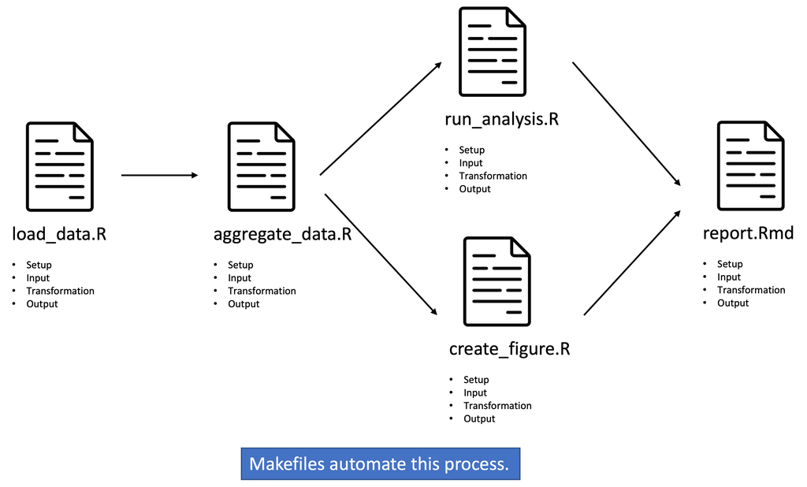

### Today's session

- Today, we're focusing on step 1 - exploring and plotting data
- …but, some of the source code will end up in your data preparation for your project.

### Part 1: RMarkdown

### Exploring data using RMarkdown

- Recall, there are multiple ways to code in R
  - RStudio
  - Your favorite script editor (e.g., VS Code) + running from the terminal
- But – in all of these cases, the output will be “ugly” (i.e., just some text)
- RMarkdown is a way to format output nicely – and ideally suited for exploring data
  - mix of code and text (formatted in markdown) - you already know the concept from Jupyter Notebook
  - possibility to compile into HTML, PDF, Word, and many more
- great for prototyping code, but bad for “production” (this is also the case for Python's Jupter Notebook)

### DO: Creating your first RMarkdown

In today's session, we create our own RMarkdown document.

1. Select file → new → RMarkdown.
2. Choose HTML as output, and pick a good file name (e.g., “tutorial”)
3. Save your `.Rmd` file.
4. Convert (“knit”/“compile”) the document to HTML by clicking on **“knit to HTML”**.

[figure not shown]

**We will continue when you're done.**

### RMarkdown basics

- We already know markdown syntax, right?
  - If not: find a cheat sheet online right now or use [this one](https://www.markdownguide.org/cheat-sheet/)
- All compiled the document? Try this first **always**!
- Navigating an RMarkdown document
  - Code cells & running code (click, ctrl/cmd+enter)
  - Using inline code
  - Options to run (or not run) code cells when compiling documents
  - that 'little wheel' (upper right)
  - `echo`, `include` parameters

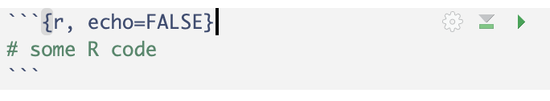

### Let's get started with exploring and auditing data

We'll make use of the **[Google Mobility Datasets](https://www.google.com/covid19/mobility/)** from The Netherlands.

1) In the tutorial on the site, you can either download the data from my server **or** get the data directly from Google (try downloading yourself). If downloading yourself, watch out for “conversion” issues.

2) In class (to smoothen things…), please just run the code snippet below:

```r
library(tidyverse)
mobility <- read_csv('https://raw.githubusercontent.com/hannesdatta/course-dprep/refs/heads/master/content/docs/modules/week2/tutorial/2020_NL_Region_Mobility_Report.csv')
```

3) Exploring the data: use `head()`, `tail()`, and `View()`/`glimpse()`

- Think yourself as a **data detective** – you just arrived at the (crime) scene, and it's time to scan for clues.
- Turn on your critical thinking mode: **Do you understand what's in the data? Are there weird patterns? What questions pop into your head?**

### Verifying data types

- `glimpse()` gives you an overview about data types and first values
- alternatively, you can use `class(mobility$date)` to inspect classes (e.g., dates, numerics, characters)
- Recall: can only calculate with dates when they are actual dates! (same with numbers: doesn't work with characters!)
- Also important to spot wrong encodings

### Build an understanding about the unit of observation/analysis

- What is it? → The level at which data is collected (e.g., individuals, groups, products, events).
- Why does it matter? → It shapes **how you summarize and interpret data**—wrong levels lead to **misleading results**.
- Example:
  - A store tracks **purchases** → Unit = **transaction**
  - To study **customer behavior**, we must **aggregate by customer** (or **customer-month**, etc.)
- Key Questions:
  - 👉 What is my current unit of analysis? [DO]
  - 👉 Is this the right level for my research question?
  - 👉 Do I need to/How could I aggregate or transform my data? [DO]

### Creating summary statistics

- We can generate summary statistics using the `summary()` command.
  - do values make sense?
  - are there any missing values?
- We can also zoom in on specific columns and create summary stats (e.g., on `retail_and_recreation_percent_change_from_baseline`) - what does it mean?

### DO: Cleaning and enriching data for exploration

- Typically, the raw data is always messy and likely not at the correct unit of analysis (e.g., city level).
- Also, we may still want to select columns, or rename them.

**Please use the `dplyr` commands `select()` (column selection), and `rename()`**.

1. Drop these columns
   - `country_region_code`
   - `metro_area`
   - `iso_3166_2_code`
   - `census_fips_code`
2. Rename
   - `sub_region_1` to `province`, and
   - `sub_region_2` to `city`

### Solutions

```r
# dropping
mobility <- mobility %>% select(-country_region_code, metro_area, iso_3166_2_code, census_fips_code)
# renaming
mobility <- mobility %>%
  rename(province = sub_region_1,
        city = sub_region_2,
        retail_and_recreation = retail_and_recreation_percent_change_from_baseline,
        grocery_and_pharmacy = grocery_and_pharmacy_percent_change_from_baseline,
        parks = parks_percent_change_from_baseline,
        transit_stations = transit_stations_percent_change_from_baseline,
        workplaces = workplaces_percent_change_from_baseline,
        residential = residential_percent_change_from_baseline)
```

### Understanding how the data is recorded

We want to understand how the data is coded; let's take a look at unique combinations of country_region, province, and city.

```r
overview <- mobility %>% group_by(country_region, province, city) %>% count()
```

DO: Run the snippet and explore it using `View()`.

### Do: Selecting subsets

- We want to create two new data sets
  - `province` only contains the observations for a province in NL (city must be missing, but province not)
  - `country` only contains observations for NL (city and province must be missing)
- Use the `dplyr` verbs `filter()`, the piping character (`%>%`), and the “NA” detector function `is.na()`

**Task: Create the two data sets: `province` and `country`.**

### Solution

Please run this snippet to be able to continue the tutorial if you have not solved it yourselves.

```r
country  <- mobility %>%
  filter(is.na(city) & is.na(province))

province <- mobility %>%
  filter(is.na(city) & !is.na(province))
# Note, the explamation sign (!) negates a TRUE into a FALSE (and the other way around)
```

### Let's talk about... Missing values (`NA`)

- Why care about missing values?
  - Missing data can **bias results** and **affect analysis**
  - Some methods ignore missing values, others break if not handled
  - Solutions depend on **why** values are missing
- Ways to explore missing values
  - `summary()`
  - `sum(is.na(columnname))`
- **DO: Explore missing values in the `country` dataset using `summary()`**
  - Which columns?
  - Are they “actual” missings?

### DO: Replacing missing values

- `mutate`: create new or edit existing column
- `ifelse(X, A, B)` does action A or B, depending on X
- `is.na(col)` checks for missing values in a column

```r
# toybox example, does not run (because this particular data doesn't exist)
new_data = old_data %>%
  mutate(new_variable = ifelse(is.na(old_variable),
                               mean(old_variable, na.rm=T),
                               old_variable))
```

**Please replace missing values by their mean for `retail_and_recreation` and other “place” columns in the `province` dataset.**

### Solution

```r
province_updated <- province %>%
  mutate(
    retail_and_recreation = ifelse(
      is.na(retail_and_recreation),
      mean(retail_and_recreation, na.rm = TRUE),
      retail_and_recreation
    ),
    grocery_and_pharmacy = ifelse(
      is.na(grocery_and_pharmacy),
      mean(grocery_and_pharmacy, na.rm = TRUE),
      grocery_and_pharmacy
    ),
    parks = ifelse(
      is.na(parks),
      mean(parks, na.rm = TRUE),
      parks
    ),
    transit_stations = ifelse(
      is.na(transit_stations),
      mean(transit_stations, na.rm = TRUE),
      transit_stations
    ),
    workplaces = ifelse(
      is.na(workplaces),
      mean(workplaces, na.rm = TRUE),
      workplaces
    ),
    residential = ifelse(
      is.na(residential),
      mean(residential, na.rm = TRUE),
      residential
    )
  )
```

### Part 2: `ggplot2`

### Visualization using `ggplot2`

- Why?
  - great plotting tool: `ggplot2` (better than built-in functionality)
  - works seamlessly with `dplyr` pipelines
  - can create really complex charts, real quick, plus export them to PDF/PNG, etc.
- Steps
  - define dataset: `ggplot(data = your_data)` or `data %>% ggplot()`
  - set aesthetics (aes) – what goes where?: `aes(x= ..., y = ...)`
  - choose geometry/chart type (`geom_`): `geom_line()`, `geom_point`, `geom_col` (barchart), `geom_hist` (histogram)
  - customize (e.g., titles, colors, themes, labels, etc.) - I use ChatGPT/Google to find tips

### DO: First chart

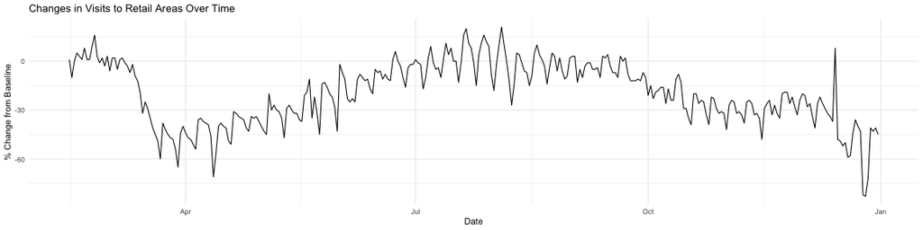

```r
library(ggplot2)
ggplot(data = country) +
  geom_line(aes(x = date, y = retail_and_recreation),
    color = "black") +
  labs(title = "Changes in Visits to Retail Areas Over Time",
       x = "Date",
       y = "% Change from Baseline") +
  theme_minimal()
```

**Your tasks:**

1. Change the color of lines to **blue**
2. Try out another theme: `theme_light()` instead of `theme_minimal()`
3. Please change the y axis from `retail_and_recreation` to `parks` + change title of plot.

### Useful to know: saving plots

We can save plots to a file by immediately calling this command after creating a plot.

```r
ggsave()
```

- Extensions:
  - `ggsave(filename = 'plot.pdf')` or `ggsave(filename = 'plot.png')` - pick any format
  - can specify `width`, `height`, `dpi`, `bg` (background), etc.
  - create directories with `dir.create()` if needed
  - wipe files using `unlink('directory_name/*.*')` (be careful)
  - You can use loops as well! It can easily create hundreds of plots!

### Extension 1: Adding more data points to a chart (manually)

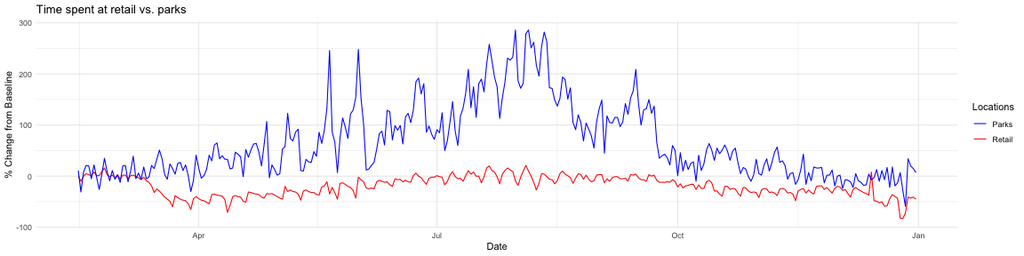

```r
library(ggplot2)
ggplot(data = country) +
  geom_line(aes(x = date,
                y = retail_and_recreation,
                color = 'Retail')) +
  geom_line(aes(x = date,
                y = parks,
                color = 'Parks')) +
  scale_color_manual(values = c("Retail" = "red",
                                "Parks" = "blue")) +
  labs(title = "Time spent at retail vs. parks",
       x = "Date",
       y = "% Change from Baseline",
       color = "Locations") +
  theme_minimal()
```

**DO: Please add a *third* data point: time spent at work (color: black).**

### Solution

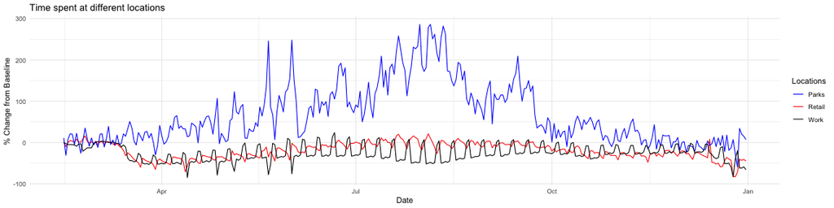

```r
library(ggplot2)
ggplot(data = country) +
  geom_line(aes(x = date,
                y = retail_and_recreation,
                color = 'Retail')) +
  geom_line(aes(x = date,
                y = parks,
                color = 'Parks')) +
  geom_line(aes(x = date,
                y = workplaces,
                color = 'Work')) +
  scale_color_manual(values = c("Retail" = "red",
                                "Parks" = "blue",
                                "Work" = "black")) +
  labs(title = "Time spent at different locations",
       x = "Date",
       y = "% Change from Baseline",
       color = "Locations") +
  theme_minimal()
```

### Extension 2: Create grouping via facet wrap

Sometimes, it makes sense “automatically” grouping our plots, such as by province!

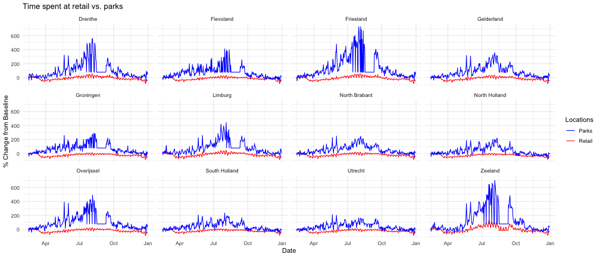

```r
province_updated %>% ggplot() +
  geom_line(aes(x = date,
                y = retail_and_recreation,
                color = 'Retail')) +
  geom_line(aes(x = date,
                y = parks,
                color = 'Parks')) +
  facet_wrap(~province) + # THIS LINE IS NEW
  scale_color_manual(values = c("Retail" = "red",
                                "Parks" = "blue")) +
  labs(title = "Time spent at retail vs. parks",
       x = "Date",
       y = "% Change from Baseline",
       color = "Locations") +
  theme_minimal()
```

### Extension 3: Grouping via a column in the data set (I)

To work on this, let's first run this cell.

```r
province_long <- province_updated %>%
  select(
    province, date,
    retail_and_recreation, grocery_and_pharmacy,
    parks, transit_stations, workplaces, residential
  ) %>%
  pivot_longer(
    cols = c(
      retail_and_recreation, grocery_and_pharmacy,
      parks, transit_stations, workplaces, residential
    ),
    names_to = "place_category",
    values_to = "mobility_change"
  )
```

This converts your “wide” data into a “long” data set (you will learn more about this in week 4).

### Extension 3: Grouping via a column in the data set (II)

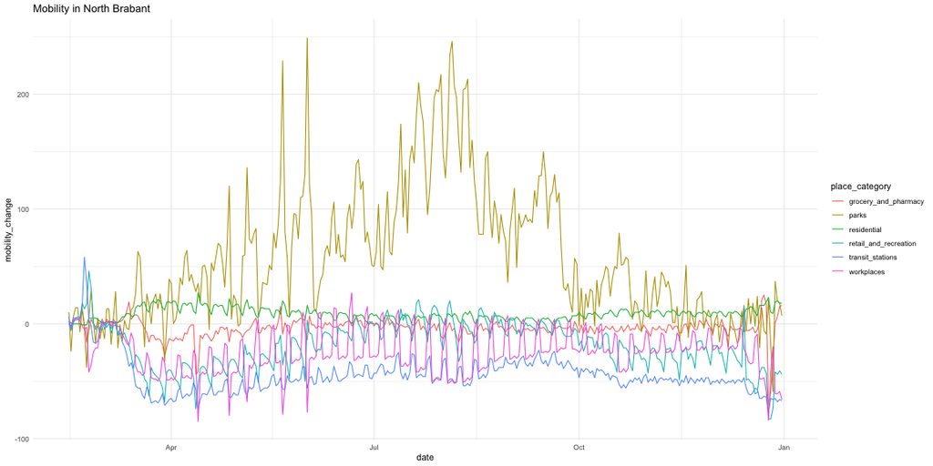

The plot now shows all locations without explicitly naming them in the code as before.

```r
province_long %>% filter(province == 'North Brabant') %>%
  ggplot(aes(x=date,
             y=mobility_change,
             color=place_category)) +
  geom_line()  +
  ggtitle('Mobility in North Brabant') +
  theme_minimal()
```

### Extension 3: Grouping via a column in the data set (III

We can also **add** a facet wrap, as in extension 2.

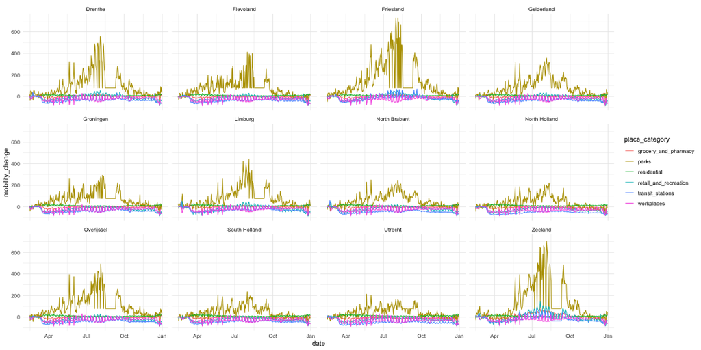

The plot now shows all locations per province.

```r
province_long %>% # no filter this time - show all provinces!
  ggplot(aes(x=date,
             y=mobility_change,
             color=place_category)) +
  geom_line()  +
  facet_wrap(~province)+
  theme_minimal()
```

### Wrapping everything up in a "clean" script

Think of this as **doing it at every end of your work cycle**.

Clean up your script(s)!

1. Setup done/packages and other prerequisites loaded?
2. Adhered to input - transformation - output?
   - input: loading data
   - transformation: filtering, grouping and summarizing, creating new variables, etc.; **mostly leads to a “different primary key than the input data” (→ unit of analysis!)**
   - output: e.g., saving plots, saving a new data set
3. Cleaned up any remaining garbage?
4. File callable from the command prompt?
   - We will need this for automation in subsequent tutorials
   - Try from the command prompt/terminal:
   - `Rscript your_r_script.R` or
   - `R --vanilla < your_r_script.R`

### Concluding thoughts

We've covered step 1! Concepts and programming knowledge extends to subsequent parts.

### Next steps

1. Work through RMarkdown & ggplot2 chapters in [R for Social Scientists](https://datacarpentry.org/r-socialsci/)
2. Work through this week's tutorial (not just “understand”, but actually “do”), see [here](https://dprep.hannesdatta.com/docs/modules/week2/tutorial/intro-to-r)
3. Coaching session: Starting up your team projects
   - Choose data set
   - pick a dataset: IMDb or Yelp
   - Find research question (but note: this course is about *engineering a research pipeline*, not about rigorously answering the RQ!!!)
   - Start your data exploration (see [workplan](https://dprep.hannesdatta.com/docs/project/workplan/))